# BIOS735 Group 6 Final project

Group 6

4/15/2022

## Introduction

The topic of our project is to improve the performance in telemarketing using predictive models. Telemarketing is a method of marketing directly to customers via phone or the Internet in order to sell goods or services. Telemarketing Industry has a market size of $23.4 bn in 2022 and is still expecting a 2% growth in market size.[ref](https://www.ibisworld.com/industry-statistics/market-size/telemarketing-call-centers-united-states/) A central challenge in telemarketing is in targeting individuals to sell goods or services. It would be costly to indiscriminately canvas everyone, but it would also be undesirable to target a random subset of the population as many potential sales could be lost. Thus, there is great interest in tools to identify the groups of individuals for whom telemarketing would likely result in sales and the groups of whom telemarketing is unlikely to be successful. Then, the firm could save resources by ignoring those in the latter group while not losing out on potential sales [1].

The goal of this project is to predict the success of telemarketing using potential customers’ key metrics. We will use predictive statistical models to predict whether a client would agree to subscribe a term deposit of future telemarketing campaigns based on historical data. The expected results for this project are: 1. Construct a ridge logistic regression model from scratch and implement in an R package that can be applied in future similar problems; 2. Fit a support vector machine model using R package and compare the results with ridge logistic regression model

The goal of this project is to build a classifier using the covariates listed in Table to predict whether or not that client subscribed a term deposit. We choose Accuracy, Kappa, Sensitivity, Specificity and F1 Score as the criterion we will use to evaluate model performance. We used logistic regression with a ridge penalty and support vector machines (SVM) as the candidate models. We also developed an R package that can be used to replicate our analysis. All analysis materials are in our Github page [Github link](https://github.com/ReneeDu320/BIOS735-Project).

Description of variables in telemarketing data set

| Feature Name | Description |
| --- | --- |
| age | numeric |
| job | type of job (categorical) |
| marital | marital status (categorical: married, divorced, single) |
| education | (categorical: unknown,secondary, primary, tertiary) |
| default | has credit in default? (binary: yes, no) |
| balance | average yearly balance, in euros (numeric) |
| housing | has housing loan? (binary: yes, no) |
| loan | has personal loan? (binary: yes, no) |
| contact | contact communication type (categorical: unknown, telephone, cellular) |
| day | last contact day of the month (numeric) |
| month | last contact month of year (categorical: jan, feb, mar, …, nov, dec) |
| duration | last contact duration, in seconds (numeric) |
| campaign | number of contacts performed during this campaign and for this client (numeric) |
| pdays | number of days that passed by after last contacted from a previous campaign (numeric) |
| previous | number of contacts performed before this campaign and for this client (numeric) |
| poutcome | outcome of previous campaign (categorical: unknown, other, failure, success) |
| outcome | has the client subscribed a term deposit? (binary: yes, no) |

## Data pre-processing

There are four datasets available. We choose the dataset with 16 features and all observations (called `bank-full.csv` on the source website). To ease computational burden, we randomly select 20 percent of the data for our analysis dataset(`dat.working`), which includes 9042 observations.

We hold out 20 percent of the data as a test set for final model performance evaluation. The remaining 80 percent of the data is used as training data to select hyperparameters in the logistic regression and SVM models.

A brief overview of some important features from the analysis dataset(`dat.working`) is as follows:

|  | no (N=7983) | yes (N=1059) | Overall (N=9042) |
| --- | --- | --- | --- |
| age |  |  |  |
| Mean (SD) | -0.00777 (0.479) | 0.0275 (0.636) | -0.00364 (0.500) |
| Median [Min, Max] | -0.0912 [-1.08, 2.26] | -0.138 [-1.03, 2.40] | -0.0912 [-1.08, 2.40] |
| job |  |  |  |
| admin. | 916 (11.5%) | 118 (11.1%) | 1034 (11.4%) |
| blue-collar | 1825 (22.9%) | 148 (14.0%) | 1973 (21.8%) |
| entrepreneur | 264 (3.3%) | 10 (0.9%) | 274 (3.0%) |
| housemaid | 218 (2.7%) | 24 (2.3%) | 242 (2.7%) |
| management | 1637 (20.5%) | 261 (24.6%) | 1898 (21.0%) |
| retired | 341 (4.3%) | 101 (9.5%) | 442 (4.9%) |
| self-employed | 273 (3.4%) | 33 (3.1%) | 306 (3.4%) |
| services | 754 (9.4%) | 77 (7.3%) | 831 (9.2%) |
| student | 140 (1.8%) | 51 (4.8%) | 191 (2.1%) |
| technician | 1356 (17.0%) | 176 (16.6%) | 1532 (16.9%) |
| unemployed | 208 (2.6%) | 52 (4.9%) | 260 (2.9%) |
| unknown | 51 (0.6%) | 8 (0.8%) | 59 (0.7%) |
| marital |  |  |  |
| divorced | 857 (10.7%) | 133 (12.6%) | 990 (10.9%) |
| married | 4932 (61.8%) | 539 (50.9%) | 5471 (60.5%) |
| single | 2194 (27.5%) | 387 (36.5%) | 2581 (28.5%) |
| education |  |  |  |
| primary | 1234 (15.5%) | 118 (11.1%) | 1352 (15.0%) |
| secondary | 4150 (52.0%) | 483 (45.6%) | 4633 (51.2%) |
| tertiary | 2293 (28.7%) | 409 (38.6%) | 2702 (29.9%) |
| unknown | 306 (3.8%) | 49 (4.6%) | 355 (3.9%) |
| balance |  |  |  |
| Mean (SD) | -0.0111 (0.498) | 0.0606 (0.555) | -0.00275 (0.505) |
| Median [Min, Max] | -0.154 [-0.890, 15.9] | -0.107 [-0.543, 8.41] | -0.149 [-0.890, 15.9] |

The following plots show some insights from the priginal dataset. People aged from 25-50 are more considered as potential customers since the density for this age group is especially high in the plot.

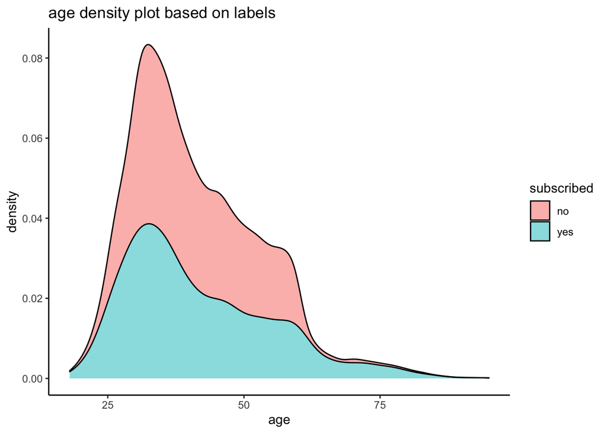

The following plot gives a distribution of mean_balance over age group. The average balance amount increased along with the increase in age. This is common that aged people typically have a higher balance compared to the young people.

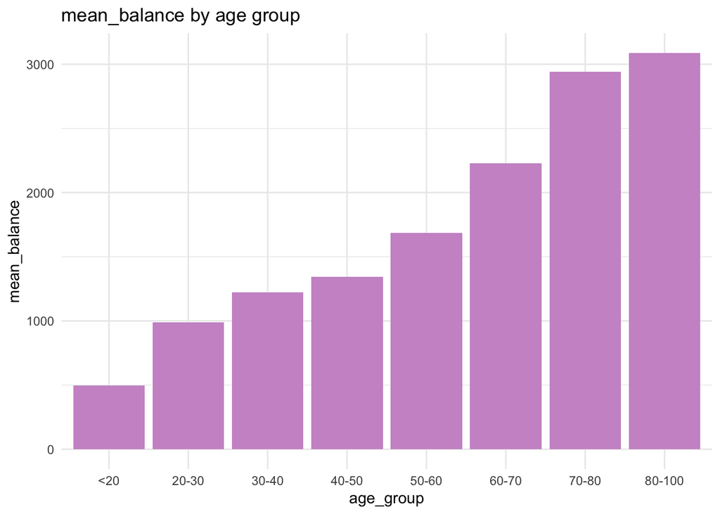

Grouping the job categories into `high_income`(including ‘admin.’‘entrepreneur,’‘management,’‘services,’‘technician’), `low_income`(including ‘blue-collar,’‘housemaid,’‘retired,’‘self-employed’), `no_income`(including ‘unemployed,’‘student’) and `unkown`(‘unkown’), the number of total compaigns sent to each group has been plotted as below: Companies are spending more efforts in engaging high-income group and low-income group, while these two groups have similar subscription rates.

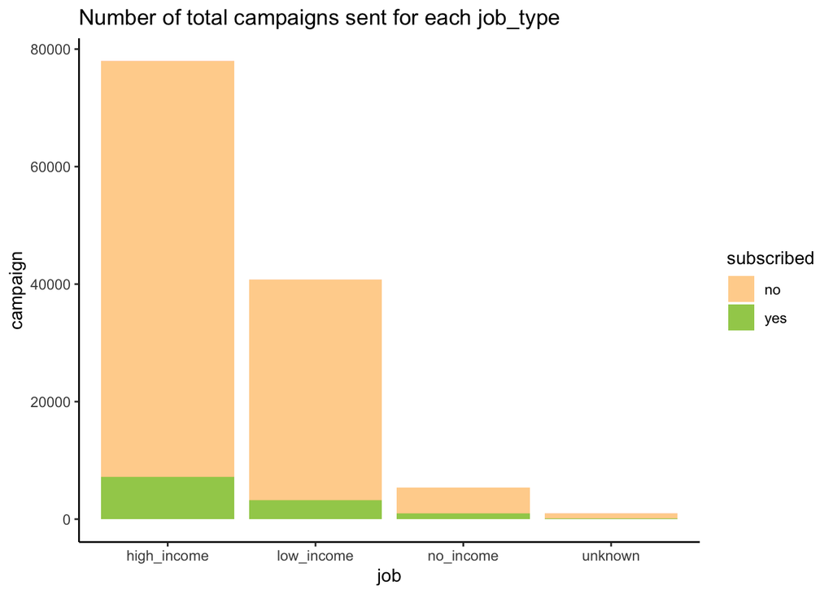

## Methods

We choose logistic regression as our likelihood-based model since it allows for classification. We consider a ridge penalty here since penalization often improves prediction, which is the primary goal. A ridge penalty is chosen as opposed to a lasso penalty since the number of features is relatively few compared to the number of observations so feature selection may be unnecessary.

Support vector machines were chosen for their flexibility and good out-of-box performance for classification. By fitting SVM using both linear and RBF kernels, we allow for flexibility in the relationship between the outcome and features.

### Logistic regression with ridge penalty

We will use the logistic regression modelling framework. We have $i=1, 2, ... , n$ subjects. We observe the outcome $Y_{i}$ for subject $i$, and we observe the subject’s covariates $x_{i}$.

Assume $y_{i}|x_{i}\sim Binomial(1, p_{i})$ for $i=1, ..., n$; $logit(p_{i})=log(\frac{p_{i}}{1-p_{i}})=x_{i}^T\beta=\eta_{i}$ for $i=1, ..., n$. Thus, the log-likelihood function of $\beta$ for the logistic regression model is given by
$$\begin{equation}
l_{n}(\beta)=\sum_{i=1}^{n}\left\{y_{i}x_{i}^T\beta-log(1+exp(x_{i}^T\beta)) \right\}
\end{equation}$$
We will use Newton-Raphson algorithm to obtain the ML estimate $\hat{\beta}$ in this GLM model by
$$\begin{equation}
\begin{aligned}
\beta^{(t+1)}&=\beta^{(t)}-l''(\beta^{(t+1)})^{-1}l'(\beta^{(t)})\\
&=\beta^{(t)}+(X^TW^{(t)}X)^{-1}X^T(Y-p^{(t)})\\
&=\beta^{(t)}+h^{(t)}
\end{aligned}
\end{equation}$$
where $p^{(t)}$ depends on $\beta^{(t)}$ and $W$ is a diagonal matrix with the $i$th diagonal element having value equal to $p_{i}(1-p_{i})$. $W^{(t)}$ is a function of $p^{(t)}$.

If we performed L2 regularization approach using ridge logistic regression [3]. The objective function is the penalized log-likelihood, and is
$$\begin{equation}
-\left[\frac{1}{N}\sum_{i=1}^{n}\left\{y_{i}x_{i}^T\beta-log(1+exp(x_{i}^T\beta)) \right\}\right]+\lambda(||\beta||_{2}),
\end{equation}$$
where $\lambda$ is a tuning parameter for the L2 the penalty. Similarly to Newton-Rapson algorithm, the optimization function to obtain the ridge estimated $\hat{\beta}_{ridge}$, the coefficients of ridge logistic regression is given by

$$\beta_{t+1} = \beta_t + (X^TWX + \lambda I_p)^{-1}X^T(y-p),$$
where the $I_p$ is a $p$ by $p$ identity matrix.

We used Iteratively Reweighted Least Squares (IRLS) [4] to perform optimization, and select the tuning parameter $\lambda$ using grid search for the $\lambda$ that yields the minimum mean square error (MSE) from cross-validation.

Both logistic regression and ridge logistic regression algorithm using IRLS approach can be summarized as follows:

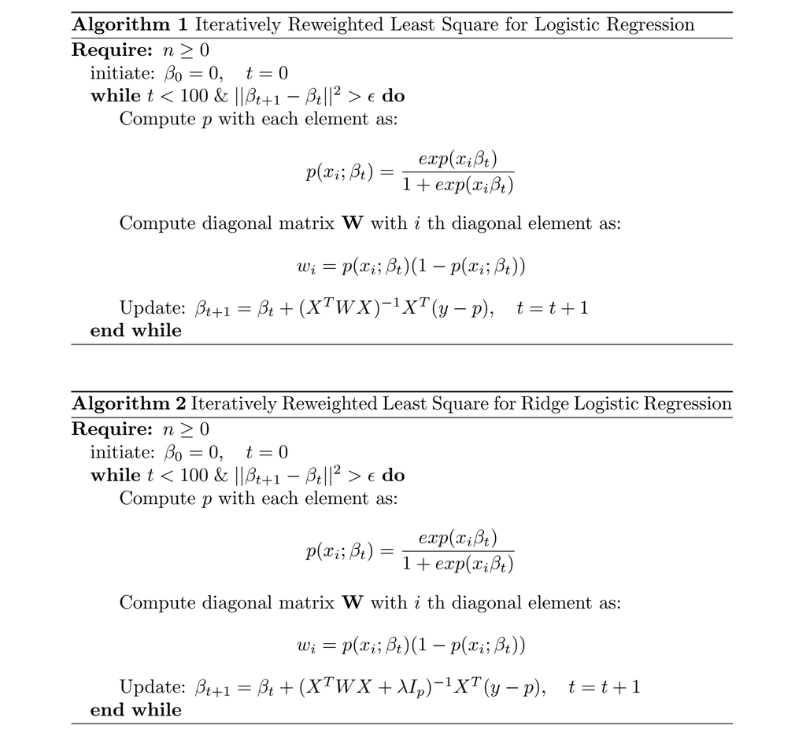

### SVM

Support vector machines (SVM) [5] are a popular machine learning method for binary classification. SVM classifies observations by separating the feature space into two classes with the goal of maximizing the number of correct classifications while allowing for some mis-classifications for identifiability and to prevent over-fitting. The form of the decision boundary is controlled by choice of the kernel function. We will fit SVM models using linear and radial kernels.

Formally, SVM solves the following Lagrangian dual

$$\begin{equation}
\begin{split}
\max_{\substack{\alpha}} \sum_{i=1}^{n} \alpha_i - \frac{1}{2} \sum_{i, j = 1}^{n} y_i y_j \alpha_i \alpha_j K(x_i, x_j) \\
\text{s.t. } 0 \leq \alpha_i \leq C, i=1,\dots, n \text{ and } \sum_{i=1}^{n} \alpha_i y_i = 0
\end{split}
\end{equation}$$

where $y \in \{-1, 1\}$ are the classification labels, $\alpha$ are the Lagrangian multipliers, $C$ is a tuning parameter chosen by cross-validation, and $K(x, x')$ represents the kernel function. The linear kernel corresponds to the dot product between $x$ and $x'$, and the radial kernel corresponds to $K(x, x') = \exp\left( \gamma ||x-x'||^2 \right)$ where $\gamma$ is a tuning parameter that will be chosen by cross-validation.

We will fit SVM using the R package [6].

### Model evaluation

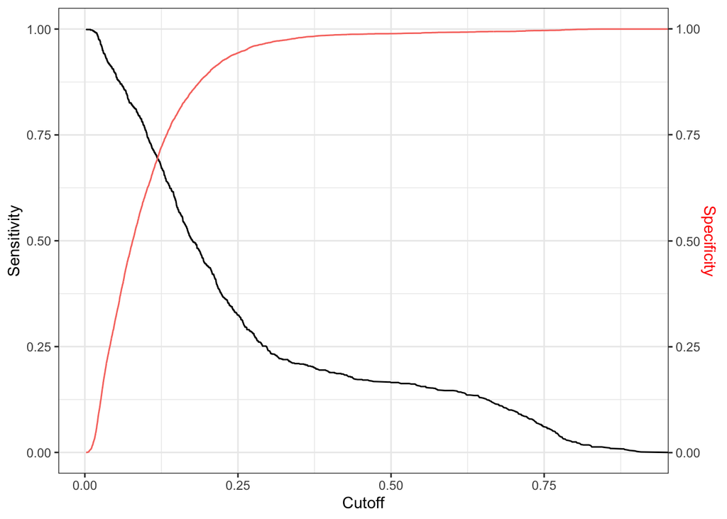

```r
# show performance metrics based off chosen cutoff
cutoff <- 0.125
predicted.classes <- ifelse(probs.ridge.test > cutoff, "yes", "no")
confusionMatrix(factor(predicted.classes, levels = c('no', 'yes')), dat_test$y, positive = 'yes')$byClass
```

```
##          Sensitivity          Specificity       Pos Pred Value
##           0.60189573           0.72243108           0.22280702
##       Neg Pred Value            Precision               Recall
##           0.93209378           0.22280702           0.60189573
##                   F1           Prevalence       Detection Rate
##           0.32522407           0.11676812           0.07028224
## Detection Prevalence    Balanced Accuracy
##           0.31543996           0.66216341
```

```r
# print confusion matrices
# NOTE: what do we want to do with these?
# are we printing them out for our own understanding?
# or will they go in final report/pres?
# (here we just want to make sure svm performs equally well on training/testing set. Only the confusion matrix on testing set needs to go in final report)
# training data; svm linear
svm.pred.lin <- predict(best.linear)
confusionMatrix(svm.pred.lin, dat_train$y, positive = 'yes')$byClass
```

```
##          Sensitivity          Specificity       Pos Pred Value
##           0.70400943           0.69547518           0.23485445
##       Neg Pred Value            Precision               Recall
##           0.94651609           0.23485445           0.70400943
##                   F1           Prevalence       Detection Rate
##           0.35221239           0.11720802           0.08251555
## Detection Prevalence    Balanced Accuracy
##           0.35134762           0.69974231
```

```r
# test data; svm linear
svm.pred.lin.test <- predict(best.linear, x.test)
confusionMatrix(svm.pred.lin.test, dat_test$y, positive = 'yes')$byClass
```

```
##          Sensitivity          Specificity       Pos Pred Value
##           0.64454976           0.69611529           0.21900161
##       Neg Pred Value            Precision               Recall
##           0.93676223           0.21900161           0.64454976
##                   F1           Prevalence       Detection Rate
##           0.32692308           0.11676812           0.07526287
## Detection Prevalence    Balanced Accuracy
##           0.34366353           0.67033253
```

```r
# training data; svm radial
svm.pred.radial <- predict(best.radial, x)
confusionMatrix(svm.pred.radial, dat_train$y, positive = 'yes')$byClass
```

```
##          Sensitivity          Specificity       Pos Pred Value
##           0.74646226           0.78628464           0.31681682
##       Neg Pred Value            Precision               Recall
##           0.95894596           0.31681682           0.74646226
##                   F1           Prevalence       Detection Rate
##           0.44483486           0.11720802           0.08749136
## Detection Prevalence    Balanced Accuracy
##           0.27615757           0.76637345
```

```r
# test data; svm radial
svm.pred.rad.test <- predict(best.radial, x.test)
confusionMatrix(svm.pred.rad.test, dat_test$y, positive = 'yes')$byClass
```

```
##          Sensitivity          Specificity       Pos Pred Value
##           0.62559242           0.74937343           0.24812030
##       Neg Pred Value            Precision               Recall
##           0.93803922           0.24812030           0.62559242
##                   F1           Prevalence       Detection Rate
##           0.35531629           0.11676812           0.07304925
## Detection Prevalence    Balanced Accuracy
##           0.29441063           0.68748293
```

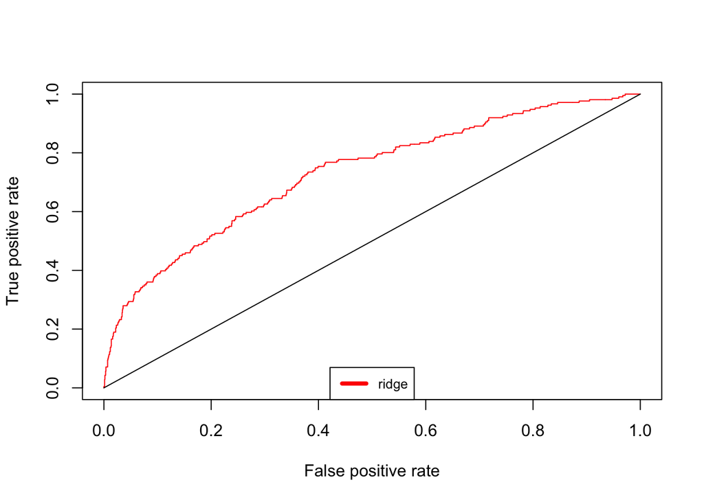

## Bibliographies

1. Marshall JJ, Vredenburg H. Successfully using telemarketing in industrial sales. Industrial Marketing Management. 1988;17:15–22.

2. Moro S, Cortez P, Rita P. A data-driven approach to predict the success of bank telemarketing. Decision Support Systems. 2014;62:22–31.

3. Zou H, Hastie T. Regularization and variable selection via the elastic net. Journal of the royal statistical society: series B (statistical methodology). 2005;67:301–20.

4. Holland PW, Welsch RE. Robust regression using iteratively reweighted least-squares. Communications in Statistics-theory and Methods. 1977;6:813–27.

5. Cortes C, Vapnik V. Support-vector networks. Machine learning. 1995;20:273–97.

6. Kuhn M. Building predictive models in r using the caret package. Journal of statistical software. 2008;28:1–26.